# Analiza wariancji - projekt

Kwiek Kamil

```r
library(tidyverse)
library(knitr)
library(kableExtra)
```

# Część 1

Zarząd firmy “Firma na A” (🍏?), która zajmuje się, między innymi sprzedażą telefonów komórkowych zastanawia się nad zmianą szaty graficznej strony, na której można dokonać zakupu ich flagowego smartfona. Przygotowali dwie nowe szaty graficzne dla strony, jedna z dużym, prostokątnym, czerwonym guzikiem “kup teraz”, druga z dużym, okrągłym, srebrnym guzikiem kup teraz. Za pomocą standardowej metodologii testu A/B/C kierowali z jednakowym prawdopodobieństwem nowych użytkowników na jedną z 3 stron. Przez 30 dni mierzyli co 6 godzin ilość sprzedanych sztuk smartfona dla każdej z wersji. Naszym zadaniem jest zbadanie za pomocą analizy wariancji i jej różnych modyfikacji odpowiedzenie na pytanie, czy nowe szaty graficzne miały wpływ na sprzedaż, a jeśli tak to która z szat jest najlepsza.

**Opis zmiennych:**

`version` - 1 - stara, 2 - prostokąt, 3 - kółko

`sales` - ilość sprzedanych sztuk

```r
sites <- readr::read_csv('C:/Users/PC/OneDrive/zadanie1.csv')
head(sites)
```

| version | sales |
| --- | --- |
| 1 | 295 |
| 1 | 115 |
| 1 | 201 |
| 1 | 251 |
| 1 | 237 |
| 1 | 320 |

## Przedstawienie danych

Na początku podzielimy nasze dane względem wersji szaty graficznej.

```r
version1 <- sites %>%
  filter(version == "1")

version2 <- sites %>%
  filter(version == "2")

version3 <- sites %>%
  filter(version == "3")
```

```r
kable(summary(version1), escape = F) %>%
  kable_styling(bootstrap_options = c("striped", "hover", "condensed"))
```

|  | version | sales |
| --- | --- | --- |
|  | Min. :1 | Min. : 34.0 |
|  | 1st Qu.:1 | 1st Qu.:160.2 |
|  | Median :1 | Median :201.5 |
|  | Mean :1 | Mean :197.0 |
|  | 3rd Qu.:1 | 3rd Qu.:237.0 |
|  | Max. :1 | Max. :335.0 |

```r
kable(summary(version2), escape = F) %>%
  kable_styling(bootstrap_options = c("striped", "hover", "condensed"))
```

|  | version | sales |
| --- | --- | --- |
|  | Min. :2 | Min. : 90.0 |
|  | 1st Qu.:2 | 1st Qu.:195.8 |
|  | Median :2 | Median :220.0 |
|  | Mean :2 | Mean :220.7 |
|  | 3rd Qu.:2 | 3rd Qu.:250.2 |
|  | Max. :2 | Max. :358.0 |

```r
kable(summary(version3), escape = F) %>%
  kable_styling(bootstrap_options = c("striped", "hover", "condensed"))
```

|  | version | sales |
| --- | --- | --- |
|  | Min. :3 | Min. : 58.0 |
|  | 1st Qu.:3 | 1st Qu.:166.0 |
|  | Median :3 | Median :198.5 |
|  | Mean :3 | Mean :199.5 |
|  | 3rd Qu.:3 | 3rd Qu.:231.0 |
|  | Max. :3 | Max. :331.0 |

Sprawdzamy wstępnie średnie w naszych podgrupach i zauważamy, że druga wersja szaty graficznej w jakiś sposób różni się od pozostałych grup. Nasze dane mają zbalansowany design - wszystkie podgrupy są tak samo liczne.

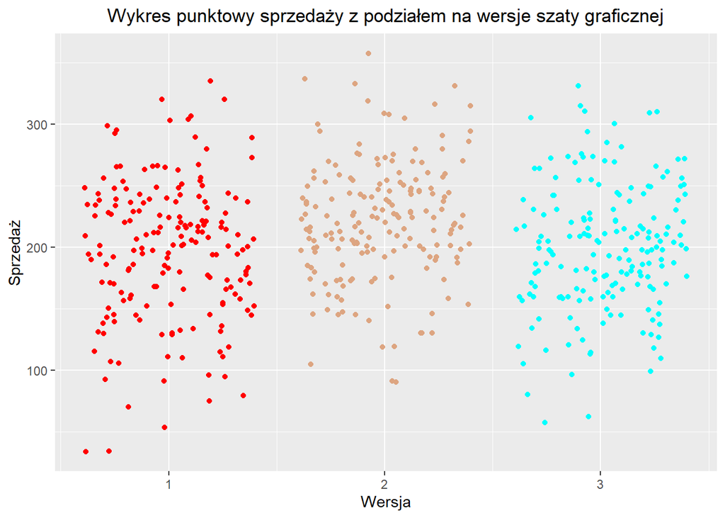

```r
ggplot(sites, aes(x=version, y=sales)) +
  geom_point(aes(color=version),position='jitter') +
  labs(title = 'Wykres punktowy sprzedaży z podziałem na wersje szaty graficznej', x='Wersja', y='Sprzedaż') +
  theme(legend.position = 'none') +
  theme(plot.title = element_text(hjust = 0.5)) +
  scale_color_gradientn(colours = rainbow(2))
```

Z powyższego wykresu zauważamy, że wersja szaty graficznej z prostokątnym guzikiem odnosi niewiele większą sprzedaż od pozostałych szat.

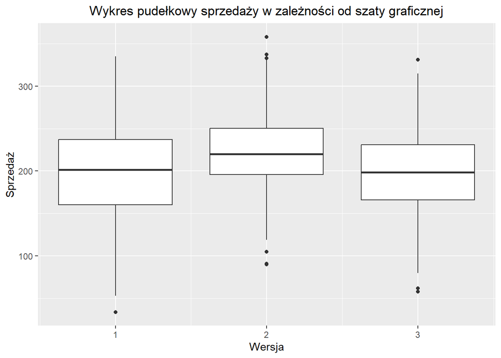

```r
ggplot(sites, aes(x = version, y = sales, group = version)) +
  geom_boxplot() +
  labs(title = "Wykres pudełkowy sprzedaży w zależności od szaty graficznej", x='Wersja', y='Sprzedaż') +
  theme(plot.title = element_text(hjust = 0.5))
```

Z wykresu pudełkowego możemy wywnioskować, iż w przypadku starej szaty graficznej “1” dane są symetryczne. Mediana znajduję się w okolicach środka pudełka. Przy minimalnej wartośi istnieje dokładnie jedna wartość odstająca. Następnie w przypadku szaty graficznej prostokątnej “2” elementy odstające znajdują się zarówno w maksymalnych wartościach jak i minimalnych. Mediana w tym przypadku również znajduję się blisko środka oraz całość jest symetryczna tak jak dla “1”. Kończąc na szacie graficznej o kształcie kółka zauważamy, iż mediana znajduję się na środku. Są dwa elementy odstające w najmniejszych wartościach oraz jeden element w `max. Całość jest również symetryczna.

## Normalność

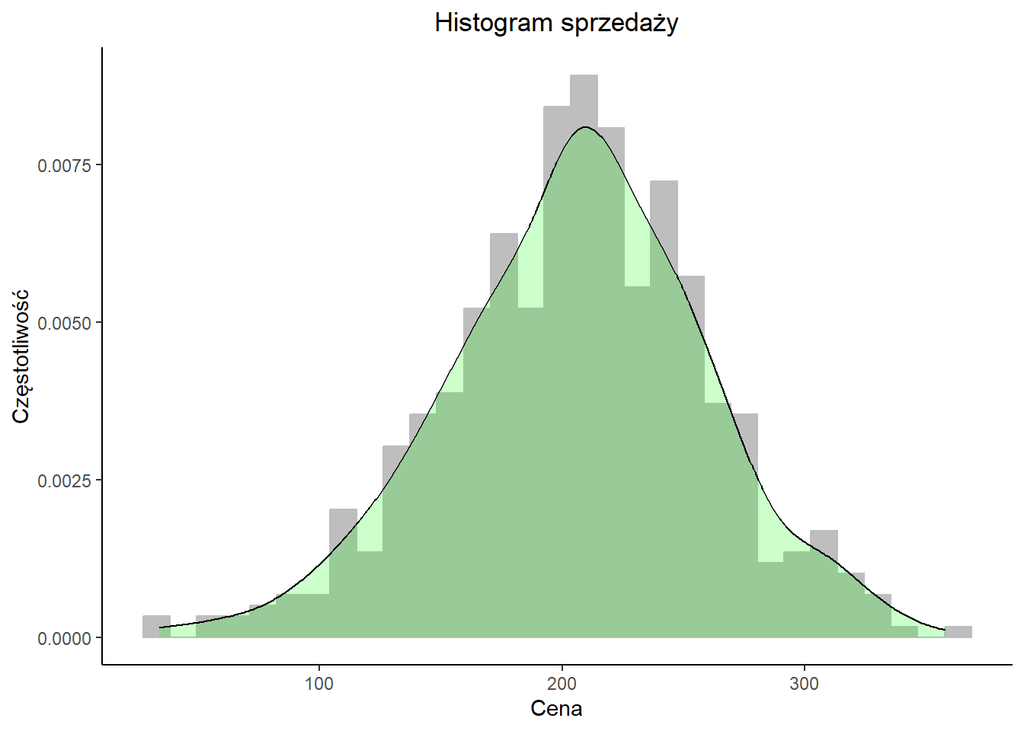

```r
ggplot(sites, aes(x=sales))+
  labs(title = 'Histogram sprzedaży',
       x = 'Cena',
       y = 'Częstotliwość') +
  geom_histogram(aes(y=..density..),
                 color="gray",
                 fill="gray",
                 binwidth = 11) +
  geom_density(alpha=.2, fill="green") +
  theme_classic() +
  theme(plot.title = element_text(hjust = 0.5))
```

```r
shapiro.test(sites$sales)
```

```
##
##  Shapiro-Wilk normality test
##
## data:  sites$sales
## W = 0.99598, p-value = 0.1859
```

Z histogramu oraz testu Shapiro-Wilka wnioskujemy, że zmienna `sales` ma rozkład normalny. Zatem przy badaniu stałej wariancji w każdej z grup skorzystamy z testu Bartletta.

## Model anova

```r
bartlett.test(sales ~ version, data = sites)
```

```
##
##  Bartlett test of homogeneity of variances
##
## data:  sales by version
## Bartlett's K-squared = 4.9298, df = 2, p-value = 0.08502
```

Wartość $p$ dla testu Bartletta wyniosła $> 0,05$, zatem wariancja w każdej z grup jest równa.

```r
anova_model_zadanie1 <- aov(sales ~ version, data=sites)
summary(anova_model_zadanie1)
```

```
##              Df  Sum Sq Mean Sq F value Pr(>F)
## version       1     548   547.6   0.192  0.661
## Residuals   538 1531120  2845.9
```

Wartość statystyki $p$ jest $> 0,05$ zatem nie mamy podstaw do odrzucenia $H_{0}$. Możemy stwierdzić, że wszystkie wartości przeciętne w grupach są takie same. Analiza wariancji nie wykazała istotnych różnic, więc nie stosujemy kolejnych testów.

## Podsumowanie

Podsumowując, możemy stwierdzić, że żadna szata graficzna nie wpływa istotnie na sprzedaż, lecz z wcześniejszych wykresów odrobinę większą sprzedaż generuje szata **nr 2**, czyli z prostokątnym, czerwonym przyciskiem “kup teraz”.

# Część 2

Kolejną z branży, którą zajmuje się firma, jest streaming video w internecie. Inżynierowie firmy stworzyli nową funkcjonalność autoodtwarzania, która ich zdaniem ma zwiększyć czas oglądania wideo podczas jednej sesji przez konkretnego użytkownika, a co za tym idzie zwiększyć przychody firmy z reklam. Ich zdaniem ta funkcjonalność szczególnie będzie działała na dzieci. Ponownie za pomocą metdologii testu A/B kierowali użytkowników z jednakowym prawdopodobieństwem na wersje strony z nowym odtwarzaczem lub ze starym. Za pomocą dwuczynnikowej analizy wariancji sprawdzimy, czy inżynierowie mieli racje.

**Opis danych:**

`group:`

- *1* – użytkownicy poniżej 16 roku życia
- *2* – użytkownicy powyżej 16 roku życia, ale poniżej 40tego
- *3* – użytkownicy powyżej 40 roku życia

`version:`

- *1* – wersja ze starym odtwarzaczem
- *2* – wersja z nowym odtwarzaczem

`time` - czas w minutach spędzony na oglądaniu w danej sesji

```r
player <- readr::read_csv('C:/Users/PC/OneDrive/zadanie2.csv')
head(player)
```

| group | time | version |
| --- | --- | --- |
| 1 | 65 | 1 |
| 1 | 60 | 2 |
| 1 | 53 | 1 |
| 1 | 65 | 1 |
| 1 | 64 | 1 |
| 1 | 65 | 1 |

## Przedstawienie danych

Dzielimy użytkowników ze względu na grupy wiekowe.

```r
group1 <- player %>%
  filter(group == "1")

group2 <- player %>%
  filter(group == "2")

group3 <- player %>%
  filter(group == "3")
```

```r
kable(summary(group1), escape = F) %>%
  kable_styling(bootstrap_options = c("striped", "hover", "condensed"))
```

|  | group | time | version |
| --- | --- | --- | --- |
|  | Min. :1 | Min. :45.00 | Min. :1.000 |
|  | 1st Qu.:1 | 1st Qu.:57.00 | 1st Qu.:1.000 |
|  | Median :1 | Median :61.00 | Median :1.000 |
|  | Mean :1 | Mean :60.83 | Mean :1.494 |
|  | 3rd Qu.:1 | 3rd Qu.:64.00 | 3rd Qu.:2.000 |
|  | Max. :1 | Max. :78.00 | Max. :2.000 |

```r
kable(summary(group2), escape = F) %>%
  kable_styling(bootstrap_options = c("striped", "hover", "condensed"))
```

|  | group | time | version |
| --- | --- | --- | --- |
|  | Min. :2 | Min. : 7.00 | Min. :1.00 |
|  | 1st Qu.:2 | 1st Qu.:18.00 | 1st Qu.:1.00 |
|  | Median :2 | Median :21.00 | Median :1.00 |
|  | Mean :2 | Mean :20.77 | Mean :1.47 |
|  | 3rd Qu.:2 | 3rd Qu.:24.00 | 3rd Qu.:2.00 |
|  | Max. :2 | Max. :37.00 | Max. :2.00 |

```r
kable(summary(group3), escape = F) %>%
  kable_styling(bootstrap_options = c("striped", "hover", "condensed"))
```

|  | group | time | version |
| --- | --- | --- | --- |
|  | Min. :3 | Min. :10.00 | Min. :1.000 |
|  | 1st Qu.:3 | 1st Qu.:19.00 | 1st Qu.:1.000 |
|  | Median :3 | Median :22.00 | Median :1.000 |
|  | Mean :3 | Mean :21.93 | Mean :1.497 |
|  | 3rd Qu.:3 | 3rd Qu.:25.00 | 3rd Qu.:2.000 |
|  | Max. :3 | Max. :35.00 | Max. :2.000 |

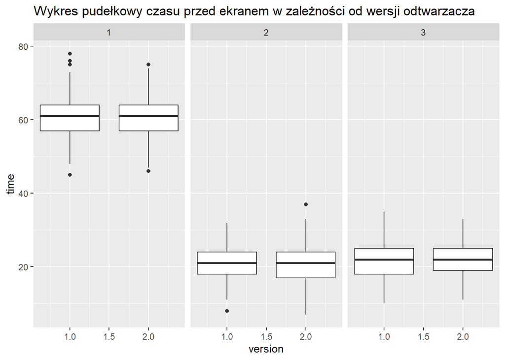

```r
ggplot(player, aes(x = version, y = time, group =version)) +
  geom_boxplot() + facet_wrap(~group) +
  labs(title = "Wykres pudełkowy czasu przed ekranem w zależności od wersji odtwarzacza")
```

Możemy wywnioskować, iż w przypadku starej jak i nowej szaty graficznej dla grupy osób poniżej 16 roku życia czas przed ekranem wyniósł znacznie więcej niż w pozostałych grupach. Mediany wszystkich grup znajdują się mniej więcej w środkowej części pudełka, a ich dokładne wartości znajdują się wyżej w polu `kable(summary(group_)`. Dla pierwszej i drugiej wersji odtwarzacza w grupie “1” i “2” istnieją wartości odstające. Wszystkie pudełka są symetryczne.

Do stworzenia modelu anova przekształcamy poziomy czynników przy użyciu `mutate -> as.factor`

```r
player <- player %>% dplyr::mutate(group = as.factor(group)) %>% dplyr::mutate(version = as.factor(version))
```

## Założenia

### Normalność prób

Dzielimy osoby z grupy pierwszej na podgrupy względem wersji odtwarzacza, z której korzytsali.

```r
version1group1 <- group1 %>% filter(version == "1")
version2group1 <- group1 %>% filter(version == "2")
```

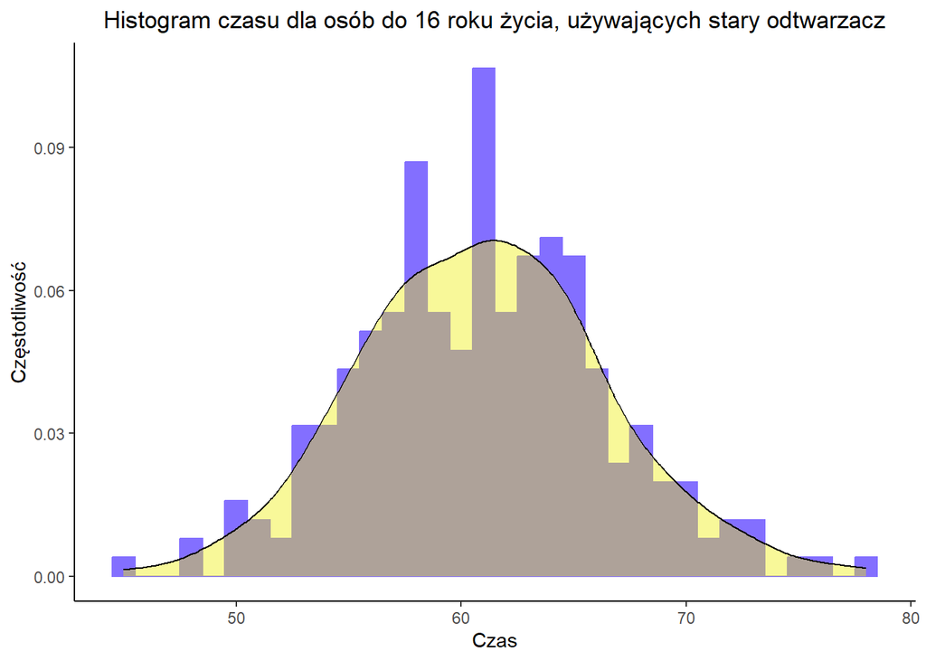

```r
ggplot(version1group1, aes(x=version1group1$time))+
  labs(title = 'Histogram czasu dla osób do 16 roku życia, używających stary odtwarzacz',
       x = 'Czas',
       y = 'Częstotliwość') +
  geom_histogram(aes(y=..density..),
                 color="slateblue1",
                 fill="slateblue1",
                 binwidth = 1) +
  geom_density(alpha=.4, fill="yellow2") +
  theme_classic() +
  theme(plot.title = element_text(hjust = 0.5))
```

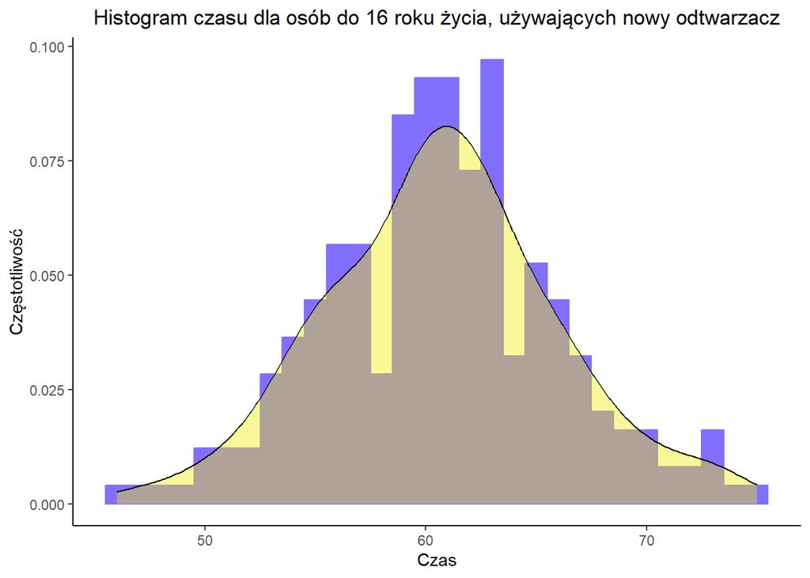

```r
ggplot(version2group1, aes(x=version2group1$time))+
  labs(title = 'Histogram czasu dla osób do 16 roku życia, używających nowy odtwarzacz',
       x = 'Czas',
       y = 'Częstotliwość') +
  geom_histogram(aes(y=..density..),
                 color="slateblue1",
                 fill="slateblue1",
                 binwidth = 1) +
  geom_density(alpha=.4, fill="yellow2") +
  theme_classic() +
  theme(plot.title = element_text(hjust = 0.5))
```

```r
shapiro.test(version1group1$time)
```

```
##
##  Shapiro-Wilk normality test
##
## data:  version1group1$time
## W = 0.99456, p-value = 0.5025
```

```r
shapiro.test(version2group1$time)
```

```
##
##  Shapiro-Wilk normality test
##
## data:  version2group1$time
## W = 0.99226, p-value = 0.2225
```

Z powyższych wynika, że rozkład zmiennej `time` dla osób do lat 16 używających zarówno stary jak i nowy odtwarzacz jest normalny. W tym wypadku, mamy możliwość ze skorzystania z testu Bartletta.

### Stałość wariancji

```r
bartlett.test(time ~ interaction(version, group), data = player)
```

```
##
##  Bartlett test of homogeneity of variances
##
## data:  time by interaction(version, group)
## Bartlett's K-squared = 14.119, df = 5, p-value = 0.01487
```

Wariancja nie jest stała. 😭

### Niezależność prób

```r
chisq.test(player$version, player$group)
```

```
##
##  Pearson's Chi-squared test
##
## data:  player$version and player$group
## X-squared = 0.67248, df = 2, p-value = 0.7145
```

Nie mamy podstaw do odrzucenia $H_0$, zatem nie występuje żadna zależność pomiędzy wersją odtwarzacza, a grupą. (Są one niezależne)

```r
shapiro.test(player$time)
```

```
##
##  Shapiro-Wilk normality test
##
## data:  player$time
## W = 0.83131, p-value < 2.2e-16
```

Dodatkowo sprawdziliśmy rozkład zmiennej `time` (nie jest normalny). Jednak nie wpływa to na założenia modelu.

## Model anova

```r
aov3 <- aov(time ~ version*group, data=player)
summary(aov3)
```

```
##                 Df Sum Sq Mean Sq  F value Pr(>F)
## version          1     42      42    1.677  0.196
## group            2 456770  228385 9156.247 <2e-16 ***
## version:group    2      5       2    0.092  0.912
## Residuals     1194  29782      25
## ---
## Signif. codes:  0 '***' 0.001 '**' 0.01 '*' 0.05 '.' 0.1 ' ' 1
```

Z modelu anova, możemy wywnioskować ,iż zmienna `group` jest statystycznie istotna. Najważniejszą zmienną czynnikową jest `group` ze względu na (***). Posiada $p-value < 0,05$, co powoduje, że zróżnicowane poziomy grup wiekowych są związane z różnym czasem poświęconym na oglądanie filmów. Natomiast zmienna `version` posiada $p-value > 0,05$, więc nie jest istotna. Możemy zatem wywnioskować, iż zróżnicowane poziomy wersji odtwarczacza wideo nie są związane z różnym czasem poświęconym na oglądanie filmów. Interakcja `version` i `group` ma wartość $p-value = 0,912$ (nieistotny) co wskazuje ,że na związek między grupą wiekową a czasem poświęconym na oglądanie video nie wpływa wersja odtwarzacza.

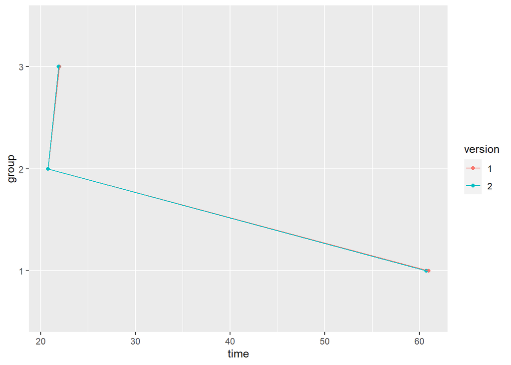

```r
ggplot(player, aes(x=time, y=group, color=version, group=version)) +
  stat_summary(fun=mean, geom = 'point') +
  stat_summary(fun=mean, geom='line')
```

# Część 3

Tym razem nie mamy bezpośrednio pytania, jedynie przedstawione dane, które zbierali inżynierowie odpowiedzialni za kolejną platformę firmy - dział przechowywania danych w chmurze. Platforma działa na zasadzie udostępniania darmowego miejsca z wolnym transferem i możliwości dokupowywania coraz większej ilości miejsca za pieniądze. Istnieje również subskrypcja, zwiększająca prędkość transferu. Korzystając z przedstawionych danych przekażemy do działu marketingu do jakiej grupy osób najlepiej skierować reklamy, aby kupowały dodatkowe miejsce w chmurze.

Komentarz: Na potrzeby tego projektu przymujemy, że jeżeli osoba zajmuje dużo miejsca w swojej chmurze, to chętniej zapłaci za więcej miejsca.

Opis danych:

`sex` - płeć

`paid` - czy użytkownik posiada płatną subskrypcje, 0 - nie, 1 - tak

`agegrp` - grupy wiekowe jak w zadaniu 2

`majoritydata` - rodzaj danych zajmujących największą część miejsca posiadanego przez użytkownika, 1 - wideo, 2 - obrazy, 3 - muzyka, 4 - inne

`active` - czy użytkownik był wgrywał jakieś pliki w przeciągu ostatnich 2 miesięcy, 0 - nie, 1 - tak

`used` - ilość zajętego miejsca w chmurze (w GB)

Przykład: Czy rodzaj danych przechowywanych przez użytkownika ma wpływ na ilość zajętego miejsca?

```r
storage <- readr::read_csv('C:/Users/PC/OneDrive/zadanie3.csv')
summary(storage)
```

```
##   majoritydata       used             sex            active
##  Min.   :1.00   Min.   : 100.0   Min.   :0.000   Min.   :0.000
##  1st Qu.:2.00   1st Qu.: 878.8   1st Qu.:0.000   1st Qu.:0.000
##  Median :3.00   Median :1079.5   Median :0.000   Median :0.000
##  Mean   :2.52   Mean   :1205.3   Mean   :0.486   Mean   :0.464
##  3rd Qu.:3.00   3rd Qu.:1393.5   3rd Qu.:1.000   3rd Qu.:1.000
##  Max.   :4.00   Max.   :3349.0   Max.   :1.000   Max.   :1.000
##      agegrp           paid
##  Min.   :1.000   Min.   :0.0000
##  1st Qu.:1.000   1st Qu.:0.0000
##  Median :2.000   Median :0.0000
##  Mean   :2.154   Mean   :0.4624
##  3rd Qu.:3.000   3rd Qu.:1.0000
##  Max.   :3.000   Max.   :1.0000
```

## Przedstawienie danych

Najpierw dzielimy osoby korzystające z chmury pod względem ich wieku.

```r
group_1 <- storage %>%
  filter(agegrp == "1") #użytkownicy poniżej 16 roku życia

group_2 <- storage %>%
  filter(agegrp == "2") #użytkownicy powyżej 16 roku życia, ale poniżej 40tego

group_3 <- storage %>%
  filter(agegrp == "3") #użytkownicy powyżej 40 roku życia
```

```r
kable(summary(group_1), escape = F) %>%
  kable_styling(bootstrap_options = c("striped", "hover", "condensed"))
```

|  | majoritydata | used | sex | active | agegrp | paid |
| --- | --- | --- | --- | --- | --- | --- |
|  | Min. :1.000 | Min. : 211.0 | Min. :0.0000 | Min. :0.0000 | Min. :1 | Min. :0.000 |
|  | 1st Qu.:1.000 | 1st Qu.: 902.5 | 1st Qu.:0.0000 | 1st Qu.:0.0000 | 1st Qu.:1 | 1st Qu.:0.000 |
|  | Median :2.000 | Median :1097.0 | Median :0.0000 | Median :0.0000 | Median :1 | Median :1.000 |
|  | Mean :2.416 | Mean :1266.5 | Mean :0.4791 | Mean :0.4388 | Mean :1 | Mean :0.505 |
|  | 3rd Qu.:3.000 | 3rd Qu.:1555.5 | 3rd Qu.:1.0000 | 3rd Qu.:1.0000 | 3rd Qu.:1 | 3rd Qu.:1.000 |
|  | Max. :4.000 | Max. :3349.0 | Max. :1.0000 | Max. :1.0000 | Max. :1 | Max. :1.000 |

```r
kable(summary(group_2), escape = F) %>%
  kable_styling(bootstrap_options = c("striped", "hover", "condensed"))
```

|  | majoritydata | used | sex | active | agegrp | paid |
| --- | --- | --- | --- | --- | --- | --- |
|  | Min. :1.000 | Min. : 138.0 | Min. :0.0000 | Min. :0.0000 | Min. :2 | Min. :0.0000 |
|  | 1st Qu.:2.000 | 1st Qu.: 891.5 | 1st Qu.:0.0000 | 1st Qu.:0.0000 | 1st Qu.:2 | 1st Qu.:0.0000 |
|  | Median :2.000 | Median :1099.5 | Median :0.0000 | Median :0.0000 | Median :2 | Median :1.0000 |
|  | Mean :2.433 | Mean :1251.0 | Mean :0.4835 | Mean :0.4435 | Mean :2 | Mean :0.5262 |
|  | 3rd Qu.:3.000 | 3rd Qu.:1471.8 | 3rd Qu.:1.0000 | 3rd Qu.:1.0000 | 3rd Qu.:2 | 3rd Qu.:1.0000 |
|  | Max. :4.000 | Max. :3042.0 | Max. :1.0000 | Max. :1.0000 | Max. :2 | Max. :1.0000 |

```r
kable(summary(group_3), escape = F) %>%
  kable_styling(bootstrap_options = c("striped","hover", "condensed"))
```

|  | majoritydata | used | sex | active | agegrp | paid |
| --- | --- | --- | --- | --- | --- | --- |
|  | Min. :1.000 | Min. : 100.0 | Min. :0.0000 | Min. :0.000 | Min. :3 | Min. :0.000 |
|  | 1st Qu.:2.000 | 1st Qu.: 854.5 | 1st Qu.:0.0000 | 1st Qu.:0.000 | 1st Qu.:3 | 1st Qu.:0.000 |
|  | Median :3.000 | Median :1038.0 | Median :0.0000 | Median :0.000 | Median :3 | Median :0.000 |
|  | Mean :2.646 | Mean :1135.2 | Mean :0.4921 | Mean :0.494 | Mean :3 | Mean :0.392 |
|  | 3rd Qu.:3.000 | 3rd Qu.:1303.5 | 3rd Qu.:1.0000 | 3rd Qu.:1.000 | 3rd Qu.:3 | 3rd Qu.:1.000 |
|  | Max. :4.000 | Max. :2919.0 | Max. :1.0000 | Max. :1.000 | Max. :3 | Max. :1.000 |

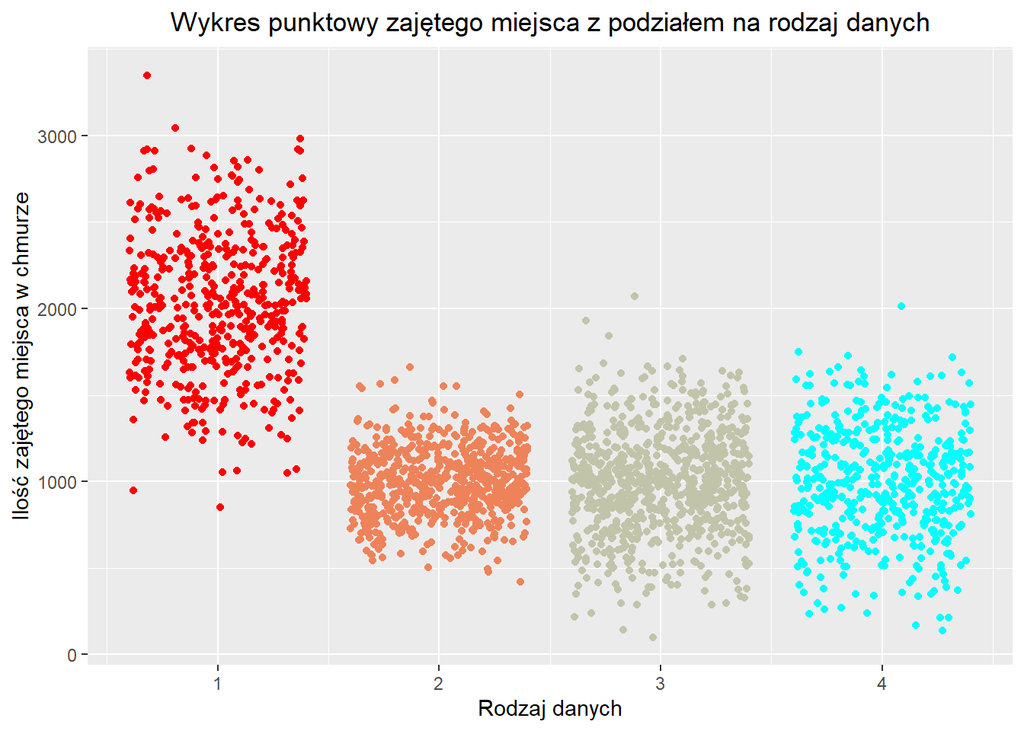

```r
ggplot(storage, aes(x=majoritydata, y=used)) +
  geom_point(aes(color=majoritydata),position='jitter') +
  labs(title = 'Wykres punktowy zajętego miejsca z podziałem na rodzaj danych', x='Rodzaj danych', y='Ilość zajętego miejsca w chmurze') +
  theme(legend.position = 'none') +
  theme(plot.title = element_text(hjust = 0.5)) +
  scale_color_gradientn(colours = rainbow(2))
```

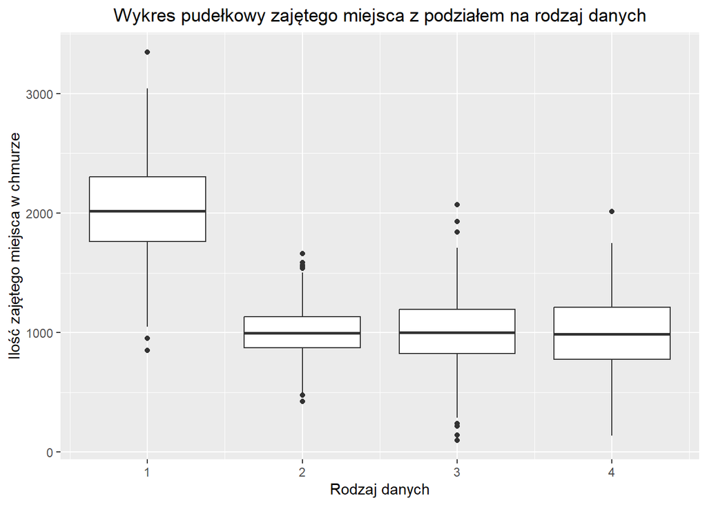

```r
ggplot(storage, aes(x = majoritydata, y = used, group = majoritydata)) +
  geom_boxplot() +
  labs(title = "Wykres pudełkowy zajętego miejsca z podziałem na rodzaj danych", x='Rodzaj danych', y='Ilość zajętego miejsca w chmurze') +
  theme(plot.title = element_text(hjust = 0.5))
```

Widzimy, że wideo zajmują najwiecej miejsca w chmurze.

```r
wideo <- storage %>%
  filter(majoritydata == "1")

obrazy <- storage %>%
  filter(majoritydata == "2")

muzyka <- storage %>%
  filter(majoritydata == "3")

inne <- storage %>%
  filter(majoritydata == "4")
```

## Założenia

### Normalność

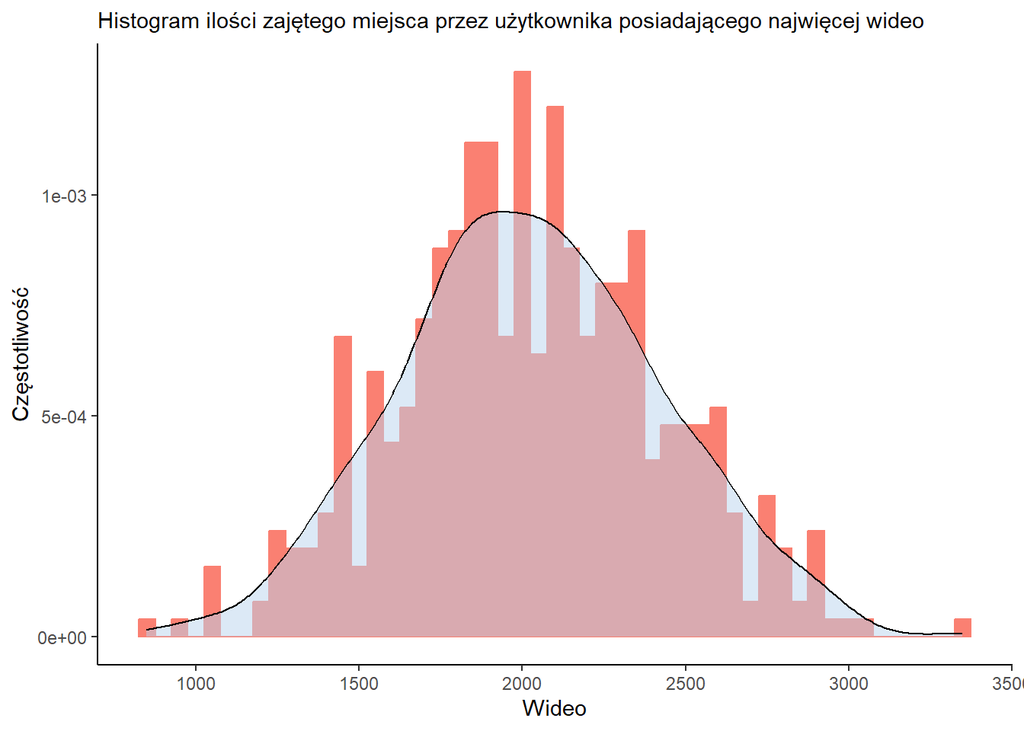

```r
ggplot(wideo, aes(x=wideo$used))+
  labs(subtitle = 'Histogram ilości zajętego miejsca przez użytkownika posiadającego najwięcej wideo',
       x = 'Wideo',
       y = 'Częstotliwość') +
  geom_histogram(aes(y=..density..),
                 color="salmon",
                 fill="salmon",
                 binwidth = 50) +
  geom_density(alpha=0.5, fill="slategray2") +
  theme_classic() +
  theme(plot.title = element_text(hjust = 0.5))
```

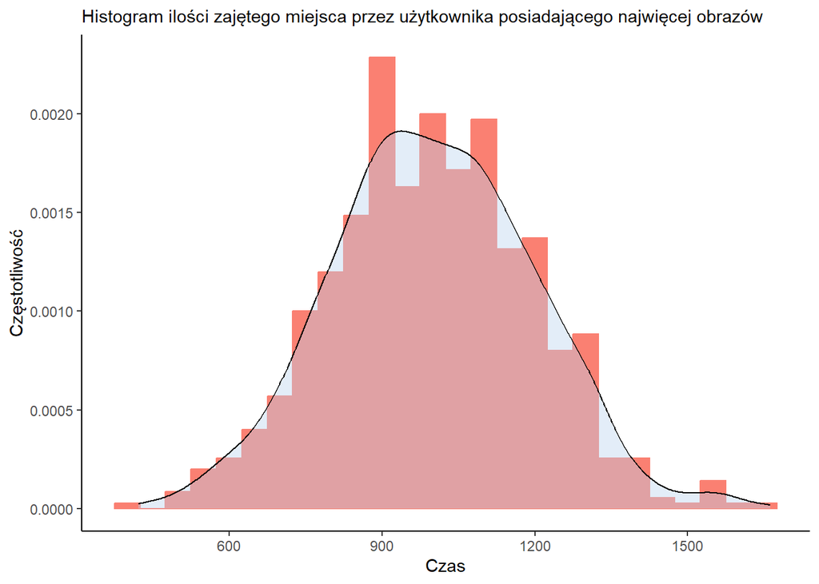

```r
ggplot(obrazy, aes(x=obrazy$used))+
  labs(subtitle = 'Histogram ilości zajętego miejsca przez użytkownika posiadającego najwięcej obrazów',
       x = 'Czas',
       y = 'Częstotliwość') +
  geom_histogram(aes(y=..density..),
                 color="salmon",
                 fill="salmon",
                 binwidth = 50) +
  geom_density(alpha=.4, fill="slategray2") +
  theme_classic() +
  theme(plot.title = element_text(hjust = 0.5))
```

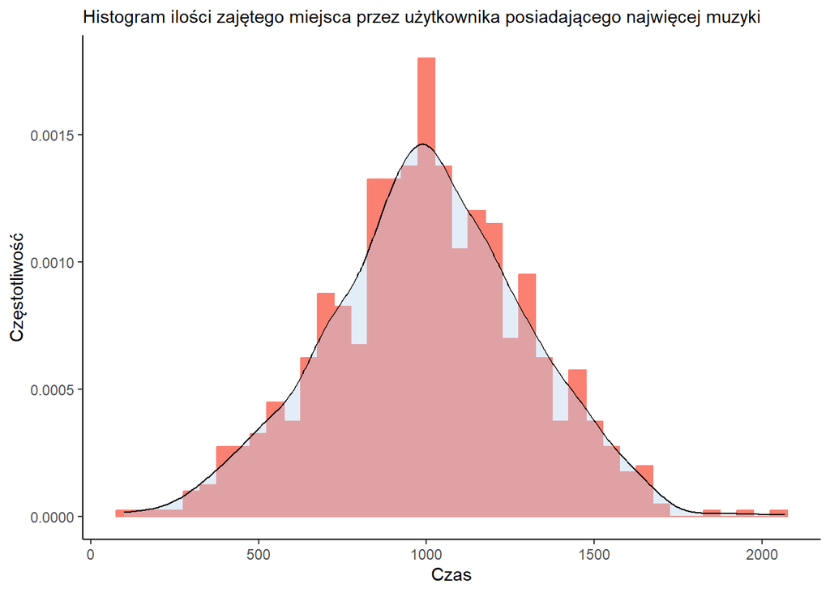

```r
ggplot(muzyka, aes(x=muzyka$used))+
  labs(subtitle = 'Histogram ilości zajętego miejsca przez użytkownika posiadającego najwięcej muzyki',
       x = 'Czas',
       y = 'Częstotliwość') +
  geom_histogram(aes(y=..density..),
                 color="salmon",
                 fill="salmon",
                 binwidth = 50) +
  geom_density(alpha=.4, fill="slategray2") +
  theme_classic() +
  theme(plot.title = element_text(hjust = 0.5))
```

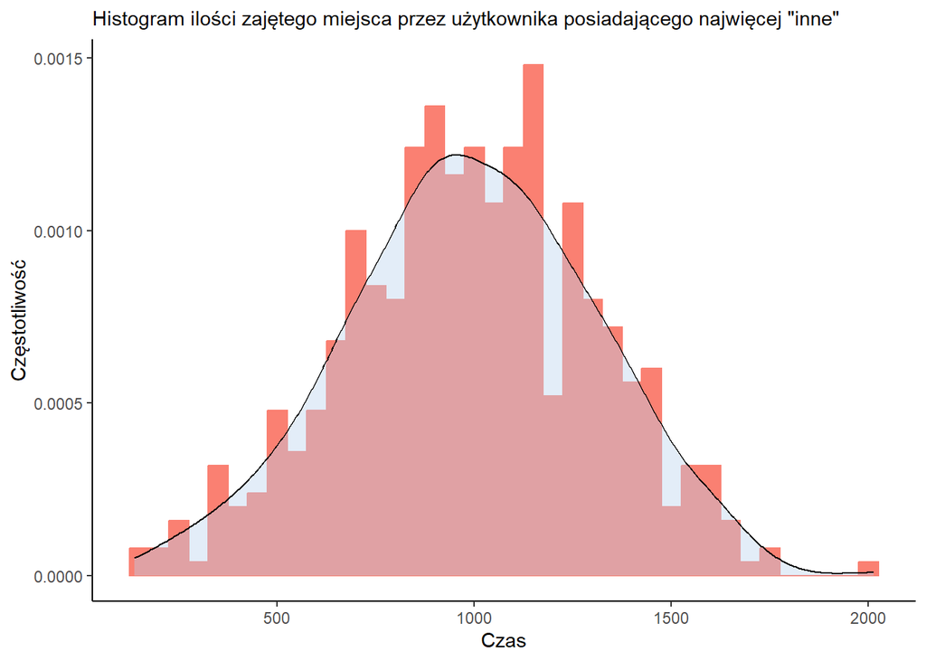

```r
ggplot(inne, aes(x=inne$used))+
  labs(subtitle = 'Histogram ilości zajętego miejsca przez użytkownika posiadającego najwięcej "inne"',
       x = 'Czas',
       y = 'Częstotliwość') +
  geom_histogram(aes(y=..density..),
                 color="salmon",
                 fill="salmon",
                 binwidth = 50) +
  geom_density(alpha=.4, fill="slategray2") +
  theme_classic() +
  theme(plot.title = element_text(hjust = 0.5))
```

```r
shapiro.test(wideo$used)
```

```
##
##  Shapiro-Wilk normality test
##
## data:  wideo$used
## W = 0.99811, p-value = 0.8606
```

```r
shapiro.test(obrazy$used)
```

```
##
##  Shapiro-Wilk normality test
##
## data:  obrazy$used
## W = 0.99805, p-value = 0.6146
```

```r
shapiro.test(muzyka$used)
```

```
##
##  Shapiro-Wilk normality test
##
## data:  muzyka$used
## W = 0.99833, p-value = 0.6463
```

```r
shapiro.test(inne$used)
```

```
##
##  Shapiro-Wilk normality test
##
## data:  inne$used
## W = 0.99764, p-value = 0.7119
```

W każdej grupie nie mamy podstaw do odrzucenia $H_0$, zatem rozkłady zmiennych: wideo, obrazy, muzyka i inne są normalne. Zatem przysępujemy do test Bartletta.

### Stałość wariancji

```r
bartlett.test(used ~ majoritydata, data = storage)
```

```
##
##  Bartlett test of homogeneity of variances
##
## data:  used by majoritydata
## Bartlett's K-squared = 293.4, df = 3, p-value < 2.2e-16
```

Wariancja nie jest stała w podanych grupach. 😭

### Niezależność prób

```r
chisq.test(storage$agegrp, storage$majoritydata)
```

```
##
##  Pearson's Chi-squared test
##
## data:  storage$agegrp and storage$majoritydata
## X-squared = 165.78, df = 6, p-value < 2.2e-16
```

Mamy podstawy do odrzucenia $H_0$, zatem istnieje zależność pomiędzy wiekiem, a typem danych, które użytkownicy przechowują.

## Model anova

```r
storagee <- storage %>% dplyr::mutate(majoritydata = as.character(majoritydata ))
```

```r
aov4 <- aov(used ~ majoritydata, data=storagee)
summary(aov4)
```

```
##                Df    Sum Sq   Mean Sq F value Pr(>F)
## majoritydata    3 423514371 141171457    1551 <2e-16 ***
## Residuals    2496 227117080     90992
## ---
## Signif. codes:  0 '***' 0.001 '**' 0.01 '*' 0.05 '.' 0.1 ' ' 1
```

Możemy stwierdzić, że nie wszystkie wartości przeciętne w grupach są takie same, zatem istnieją różnice. Więc przystępujemy do testu Tukey’a.

```r
TukeyHSD(aov4)
```

```
##   Tukey multiple comparisons of means
##     95% family-wise confidence level
##
## Fit: aov(formula = used ~ majoritydata, data = storagee)
##
## $majoritydata
##             diff         lwr        upr     p adj
## 2-1 -1028.002286 -1073.40912 -982.59545 0.0000000
## 3-1 -1024.871750 -1069.08031 -980.66319 0.0000000
## 4-1 -1036.682000 -1085.72699 -987.63701 0.0000000
## 3-2     3.130536   -37.00382   43.26489 0.9971465
## 4-2    -8.679714   -54.08655   36.72712 0.9610252
## 4-3   -11.810250   -56.01881   32.39831 0.9021767
```

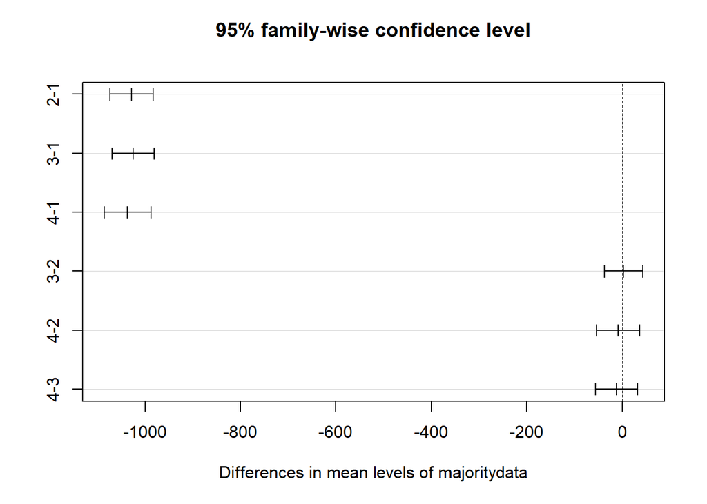

```r
plot(TukeyHSD(aov4))
```

## Podsumowanie

Zatem typ danych wgrywanych przez użytkownika ma wpływ na ilość zajętego miejsca w chmurze. Osoby, które posiadają najwięcej wideo chętniej zapłacą za więcej miejsca w chmurze, więc najlepiej do nich kierować reklamy.